# Final Data Analysis

Elyse McCormick

2022-12-14

```r
# Clear Environment

rm(list = ls())

# Load packages
library(here)
```

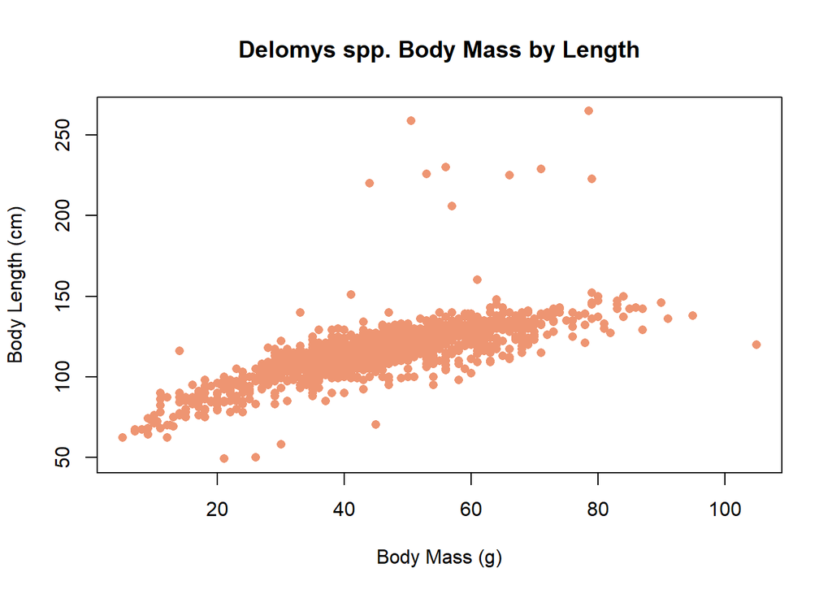

```r
# Load data
delomys_dat = read.csv(here("data", "delomys.csv"))

#Visualize with scatterplot
plot(x = delomys_dat$body_mass, y = delomys_dat$body_length,
     main = "Delomys spp. Body Mass by Length", xlab = "Body Mass (g)",
     ylab = "Body Length (cm)", pch = 16, col = "lightsalmon2")
```

**Q1 (2 pts.): Qualitatively describe the relationship between body mass and length. Does the relationship seem linear, curved, nonexistent?**

The relationship between body mass and body length seems mostly linear, but left-skewed with an array of outliers.

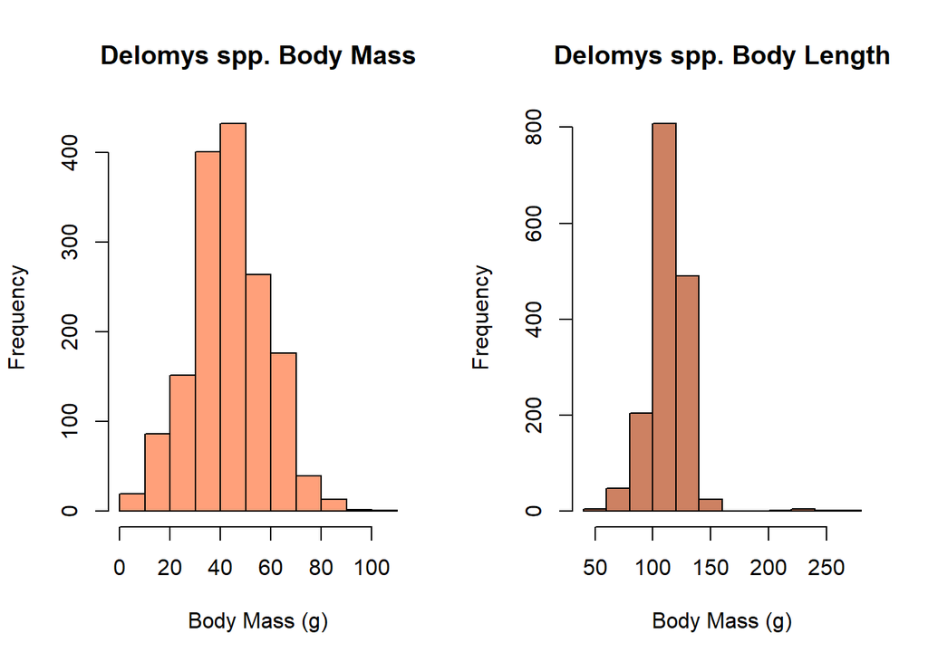

```r
#Visualize with histograms
par(mfrow = c(1,2))
hist(x = delomys_dat$body_mass, main = "Delomys spp. Body Mass",
     xlab = "Body Mass (g)", col = "lightsalmon")
hist(x = delomys_dat$body_length, main = "Delomys spp. Body Length",
     xlab = "Body Mass (g)", col = "lightsalmon3")
```

**Q2 (2 pts.): Qualitatively describe the shapes of the histograms. Do the data appear normally-distributed? Explain why or why not.Explain why we care (or not) whether the data are normally distributed.**

Body mass seems relatively normally distributed around 40 g, but the middle of the curve is much higher than the rest of the dataset, indicating it’s not a perfectly normal distribution.

Body length is not normally distributed, with what is almost a peak at 100 cm, and very little spread, indicating leptokurtosis. This also indicates it is not a normal distribution.

```r
#Summary of the data, summary by column, and Shapiro tests for normality
summary(delomys_dat)
```

```
##   observation       genus             binomial           body_mass
##  Min.   :27526   Length:1585        Length:1585        Min.   :  5.00
##  1st Qu.:27950   Class :character   Class :character   1st Qu.: 35.00
##  Median :28348   Mode  :character   Mode  :character   Median : 43.00
##  Mean   :28371                                         Mean   : 44.06
##  3rd Qu.:28790                                         3rd Qu.: 54.00
##  Max.   :35552                                         Max.   :105.00
##   body_length        age                sex              longitude
##  Min.   : 49.0   Length:1585        Length:1585        Min.   :-49681671
##  1st Qu.:106.0   Class :character   Class :character   1st Qu.:      -50
##  Median :116.0   Mode  :character   Mode  :character   Median :      -50
##  Mean   :114.7                                         Mean   :   -62739
##  3rd Qu.:124.0                                         3rd Qu.:      -47
##  Max.   :265.0                                         Max.   :      -41
##     latitude            status
##  Min.   :-22383667   Length:1585
##  1st Qu.:      -29   Class :character
##  Median :      -29   Mode  :character
##  Mean   :   -28272
##  3rd Qu.:      -24
##  Max.   :      -20
```

```r
summary(delomys_dat$body_mass)
```

```
##    Min. 1st Qu.  Median    Mean 3rd Qu.    Max.
##    5.00   35.00   43.00   44.06   54.00  105.00
```

```r
summary(delomys_dat$body_length)
```

```
##    Min. 1st Qu.  Median    Mean 3rd Qu.    Max.
##    49.0   106.0   116.0   114.7   124.0   265.0
```

```r
shapiro.test(delomys_dat$body_mass)
```

```
##
##  Shapiro-Wilk normality test
##
## data:  delomys_dat$body_mass
## W = 0.99506, p-value = 4.33e-05
```

```r
shapiro.test(delomys_dat$body_length)
```

```
##
##  Shapiro-Wilk normality test
##
## data:  delomys_dat$body_length
## W = 0.87609, p-value < 2.2e-16
```

**Q3 (2 pts.): Using both the histograms and normality tests, do you think the (unconditioned) body masses and body length are normally-distributed?Make sure you contrast your visual assessment of normality to the results of the numerical normality tests.**

Between both the histograms and the Shapiro-Wilk tests, I don’t think these data are normally distributed. As described in question 2, neither histogram is perfectly normally distributed. Similarly, the p values of the Shapiro-Wilk tests showed p < 0.05 (body mass: p = 4.33e-05, body length: p = 2.2e-16), indicating that the data are not normally distributed.

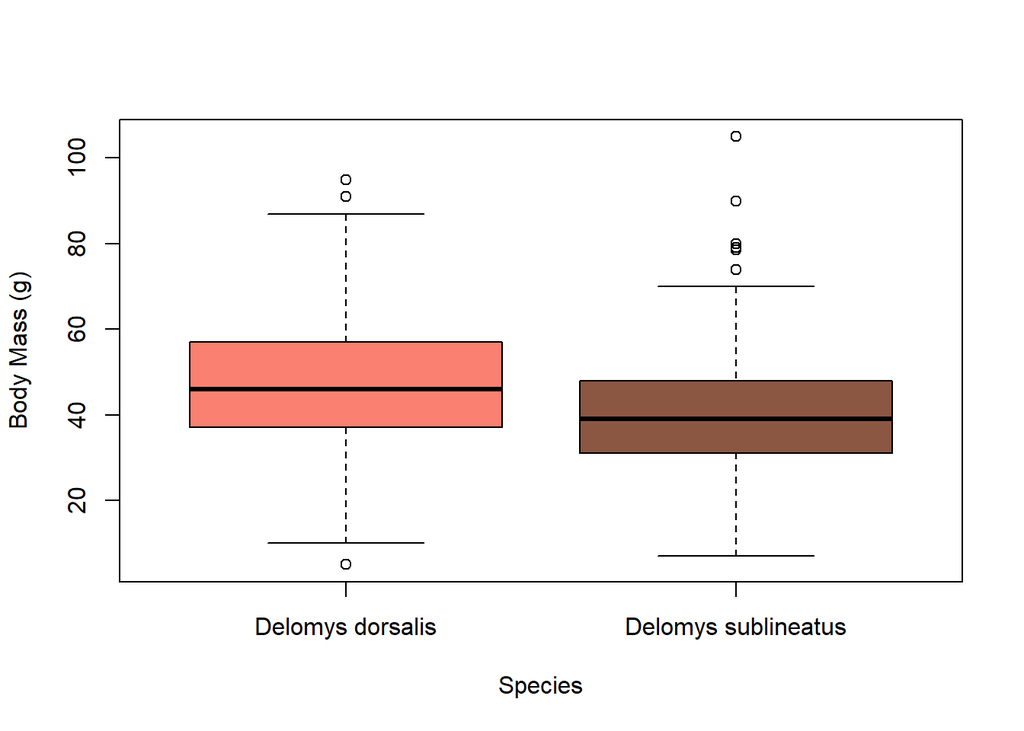

```r
#Visualize with boxplots
boxplot(body_mass ~ binomial, data = delomys_dat, xlab = "Species", ylab = "Body Mass (g)", col = c("salmon","lightsalmon4"))
```

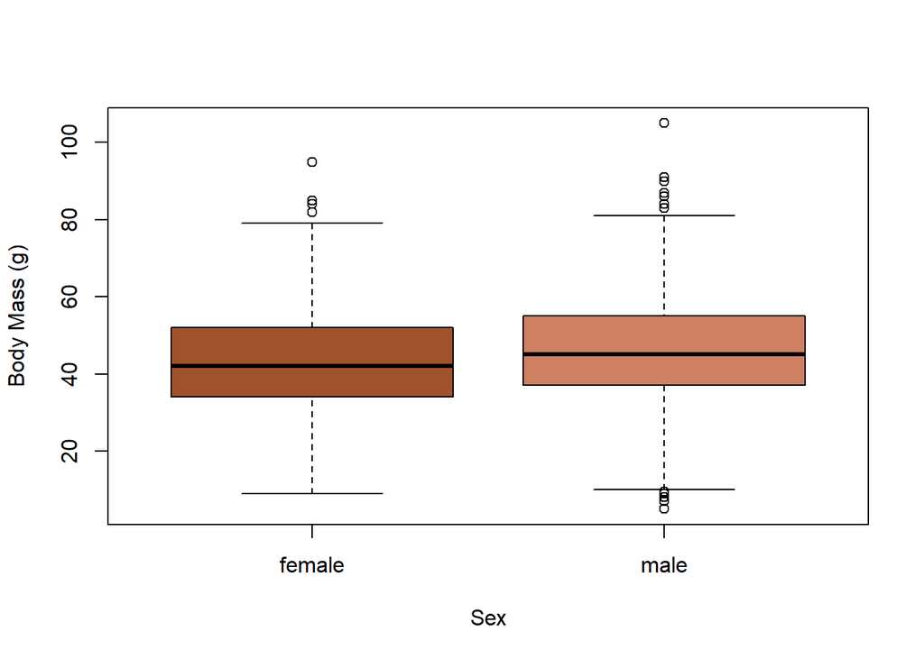

```r
boxplot(body_mass ~ sex, data = delomys_dat, xlab = "Sex", ylab = "Body Mass (g)", col = c("sienna", "lightsalmon3"))
```

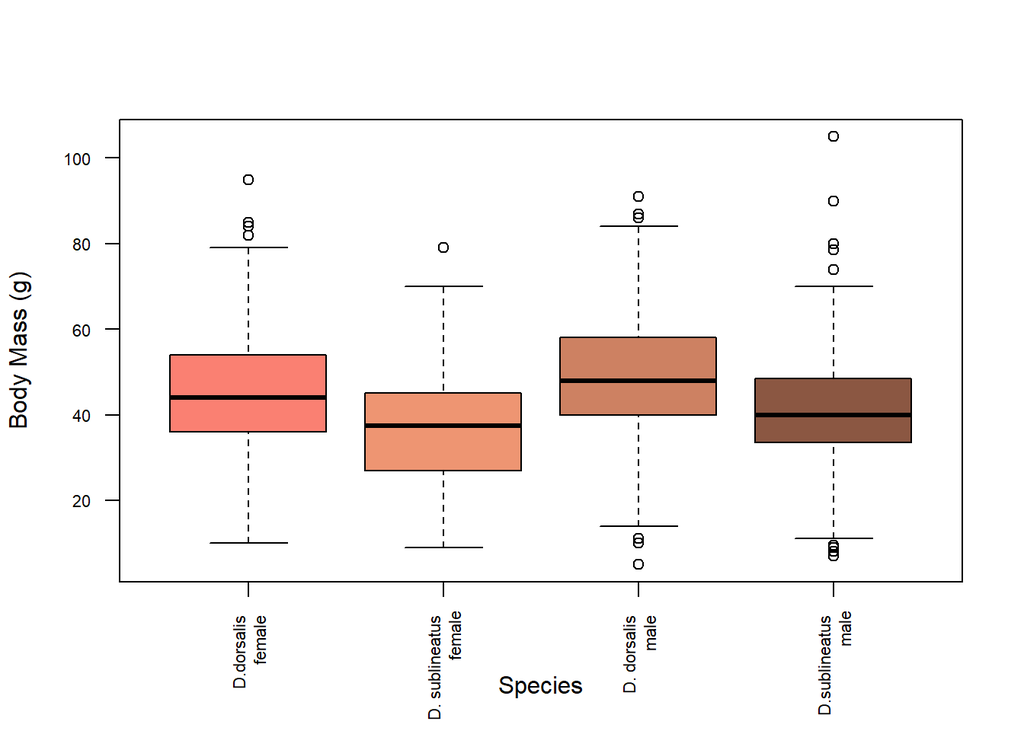

```r
boxplot(body_mass ~ binomial*sex, data = delomys_dat, xlab = "Species", ylab = "Body Mass (g)",
        las = 2,
      cex.axis= .7,
      names = c("D.dorsalis \n female ", "D. sublineatus \n female",
                  "D. dorsalis \n male ", "D.sublineatus \n male"), col = c("salmon", "lightsalmon2", "light salmon3", "lightsalmon4"))
```

**Q4 (2 pts.): Examine the three conditional boxplots.Describe any graphical evidence you see for body mass differences based on species and/or sex.**

**Q5 (2 pts.): What do you conclude about residual normality based on the numerical and graphical diagnostics?**

```r
# Create linear models
fit1 <- lm(delomys_dat$body_length ~ delomys_dat$body_mass)
fit2 <- lm(delomys_dat$body_mass ~ delomys_dat$sex)
fit3 <- lm(delomys_dat$body_mass ~ delomys_dat$binomial)
fit4 <- lm(delomys_dat$body_mass ~ delomys_dat$sex + delomys_dat$binomial)
fit5 <- lm(delomys_dat$body_mass ~ delomys_dat$sex * delomys_dat$binomial)

# Residuals
fit1res <- residuals(fit1)
fit2res <- residuals(fit2)
fit3res <- residuals(fit3)
fit4res <- residuals(fit4)
fit5res <- residuals(fit5)

#Shapiro-Wilk Test for Normality on Residuals
shapiro.test(fit1res)
```

```
##
##  Shapiro-Wilk normality test
##
## data:  fit1res
## W = 0.73462, p-value < 2.2e-16
```

```r
shapiro.test(fit2res)
```

```
##
##  Shapiro-Wilk normality test
##
## data:  fit2res
## W = 0.99563, p-value = 0.0001541
```

```r
shapiro.test(fit3res)
```

```
##
##  Shapiro-Wilk normality test
##
## data:  fit3res
## W = 0.99535, p-value = 8.103e-05
```

```r
shapiro.test(fit4res)
```

```
##
##  Shapiro-Wilk normality test
##
## data:  fit4res
## W = 0.99525, p-value = 6.805e-05
```

```r
shapiro.test(fit5res)
```

```
##
##  Shapiro-Wilk normality test
##
## data:  fit5res
## W = 0.99526, p-value = 6.816e-05
```

```r
#None of these are normally distributed

#Linear Regression summaries
knitr::kable(coef(summary(fit1)))
```

|  | Estimate | Std. Error | t value | Pr(>\|t\|) |
| --- | --- | --- | --- | --- |
| (Intercept) | 76.1246565 | 0.9158120 | 83.12258 | 0 |
| delomys_dat$body_mass | 0.8754988 | 0.0196905 | 44.46298 | 0 |

```r
knitr::kable(coef(summary(fit2)))
```

|  | Estimate | Std. Error | t value | Pr(>\|t\|) |
| --- | --- | --- | --- | --- |
| (Intercept) | 42.711465 | 0.5288929 | 80.756355 | 0.0000000 |
| delomys_dat$sexmale | 2.784133 | 0.7456117 | 3.734024 | 0.0001951 |

```r
knitr::kable(coef(summary(fit3)))
```

|  | Estimate | Std. Error | t value | Pr(>\|t\|) |
| --- | --- | --- | --- | --- |
| (Intercept) | 46.752427 | 0.4499933 | 103.89582 | 0 |
| delomys_dat$binomialDelomys sublineatus | -7.683058 | 0.7604562 | -10.10322 | 0 |

```r
knitr::kable(coef(summary(fit4)))
```

[output not shown]

```r
knitr::kable(coef(summary(fit5)))
```

[output not shown]

**Q6 (1 pt.): Are violations of the normality assumption equally severe for all the models?**

**Q7 (2 pts.): What is the magnitude of the mass/length relationship?**

The magnitude of the mass/length relationship is the mean estimate, which in model 1 is 0.8755.

**Q8 (2 pts.): What is the expected body length of an animal that weighs 100g?**

```r
76.12 + (100 *0.8766)
```

```
## [1] 163.78
```

**Q9 (2 pts.): What is the expected body length of an animal that weighs 0g?**

The expected body length is 0 cm logically, but the table says 76.12 cm.

**Q10 (1 pt.): What is the base level for sex?**

Female

**Q11 (1 pt.): What is the base level for binomial?**

*D. dorsalis*

**Q12 (1 pt.): Which sex is heavier? How do you know?**

Males. The intercept is the female mass, which means that the mass of the females (intercept) is added to the male mass value.

**Q13 (1 pt.): Which species is heavier? How do you know?**

*Delomys dorsalis* is heavier. They are the intercept, and *D. sublineatus* is negative, meaning their mass would be subtracted from the intercept, which would make their mass less than *D. dorsalis*.

**Q14 (1 pt.): Are sex and species significant predictors for body mass?**

Yes, sex and species are significant predictors for body mass.

**Q15 (1 pt.): Is there a significant interaction?**

No, there is not a significant factorial interaction between them, but there is an additive effect between species and sex.

```r
#AIC

AIC(fit1)
```

```
## [1] 12291.67
```

```r
AIC(fit2)
```

```
## [1] 13006.8
```

```r
AIC(fit3)
```

```
## [1] 12966.36
```

```r
AIC(fit4)
```

```
## [1] 12896.73
```

```r
AIC(fit5)
```

```
## [1] 12898.72
```

**Q17 (1 pt.): Which two models have the lowest AIC?**

Models fit1 and fit4 have the lowest AIC scores.

**Q18 (4 pts.): Which of the two models with lowest AIC scores would you select? Explain your decision based on model fit and the complexity/understanding tradeoff.**